# QTL analysis of morphine tolerance in a (B6 × 129<sub>3</sub>)F<sub>2</sub> cross

This tutorial will take you through the process of mapping a QTL and searching for candidate genes using morphine tolerance as the trait assayed in an F<sub>2</sub> population.

Please refer to the following publication for additional details [Kest , et al. (2004) (*Mamm Genome* 8:610-7)](https://rd.springer.com/article/10.1007/s00335-004-2367-3)

## Installation of required R packages

By now you would have all ready installed the required R packages necessary for the successful completion of this module. If you have **NOT**, please do so now by following the instructions below by pasting them in the R console:

1. [qtl](http://www.rqtl.org/) - install.packages(“qtl”)

### Load and explore the data

```r
bxa <- read.cross(format="csv", file="../data/tolerance4.csv", genotypes = c("A","H","B"), alleles = c("A","B")
                  , estimate.map =TRUE)
```

```
##  --Read the following data:
##   124  individuals
##   87  markers
##   7  phenotypes
##  --Cross type: f2
```

```r
summary(bxa)
```

```
##     F2 intercross
##
##     No. individuals:    124
##
##     No. phenotypes:     7
##     Percent phenotyped: 100 94.4 93.5 94.4 92.7 65.3 65.3
##
##     No. chromosomes:    19
##         Autosomes:      1 2 3 4 5 6 7 8 9 10 11 12 13 14 15 16 17 18 19
##
##     Total markers:      87
##     No. markers:        7 5 4 4 7 5 5 5 4 5 5 4 4 5 4 4 4 2 4
##     Percent genotyped:  96.2
##     Genotypes (%):      AA:24.3  AB:52.2  BB:23.5  not BB:0.0  not AA:0.0
```

### Set up for scanning by calculating genotype probabilities.

```r
bxa <- calc.genoprob(bxa, step=1, stepwidth="fixed", map.function="c-f", err=0.002)
```

### One dimensional genome scan

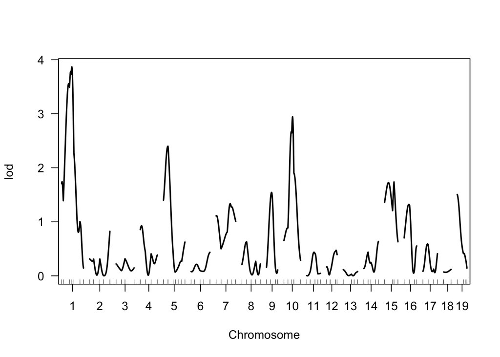

```r
bxa.scan1a <- scanone(bxa, pheno.col="sqrdep", method="hk")
plot(bxa.scan1a)
```

### Run permutations.

```r
bxa.perm1a <-scanone(bxa, pheno.col="sqrdep", method="hk", n.perm=100, perm.Xsp=TRUE)
```

```
## Doing permutation in batch mode ...
```

### Plot the genome scan.

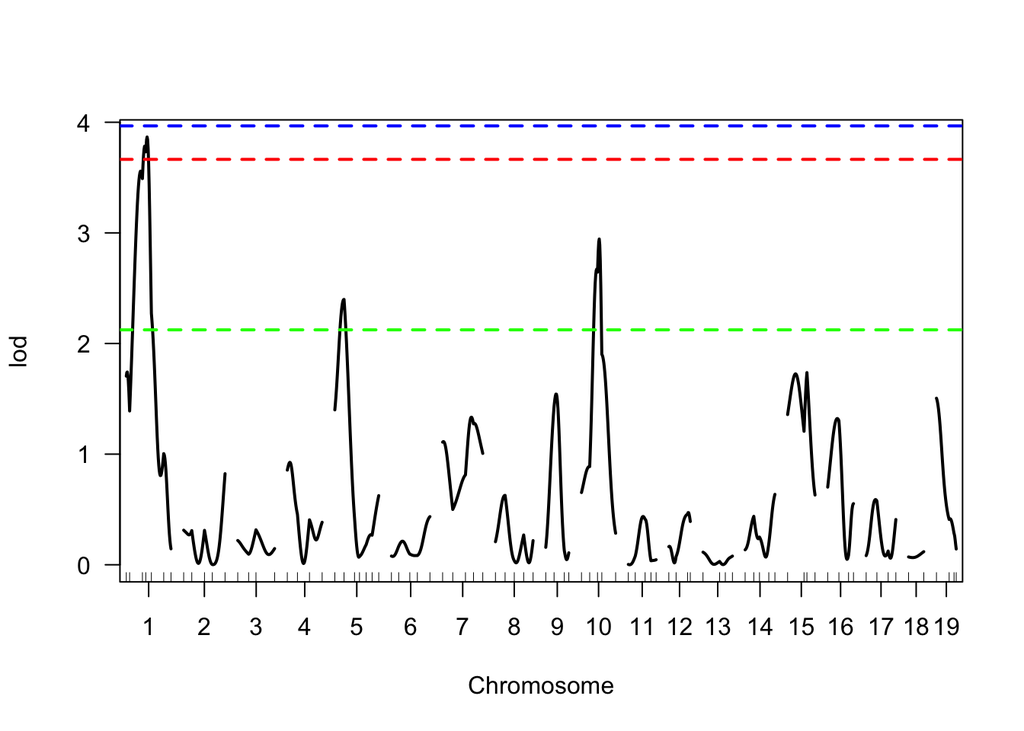

```r
plot(bxa.scan1a)
add.threshold(bxa.scan1a, perms=bxa.perm1a, alpha=0.01,lty="dashed",lwd=2,col="blue")
add.threshold(bxa.scan1a, perms=bxa.perm1a, alpha=0.05,lty="dashed",lwd=2,col="red")
add.threshold(bxa.scan1a, perms=bxa.perm1a, alpha=0.63,lty="dashed",lwd=2,col="green")
```

### Tabular summary options

```r
summary(bxa.scan1a, 2.0)
```

|  | chr | pos | lod |
| --- | --- | --- | --- |
| c1.loc41 | 1 | 47.283 | 3.866755 |
| c5.loc18 | 5 | 21.480 | 2.398494 |
| c10.loc35 | 10 | 42.000 | 2.944391 |

```r
summary(bxa.scan1a, perms=bxa.perm1a, alpha=0.10)
```

|  | chr | pos | lod |
| --- | --- | --- | --- |
| c1.loc41 | 1 | 47.283 | 3.866755 |

```r
summary(bxa.scan1a, perms=bxa.perm1a, alpha=0.10, format="tabByCol",ci.function="lodint")
```

```
##          chr  pos ci.low ci.high  lod
## c1.loc41   1 47.3   20.3    55.7 3.87
```

### Find nearest marker

Now let’s find the nearest marker to the chromosome 1 peak.

```r
find.marker(bxa, 1, 47.3)
```

```
## [1] "D1MIT48"
```

### Two dimensional genome scan

```r
bxa.scan2a <- scantwo(bxa, pheno.col="sqrdep", method="hk")
```

### Plot the pairwise scan

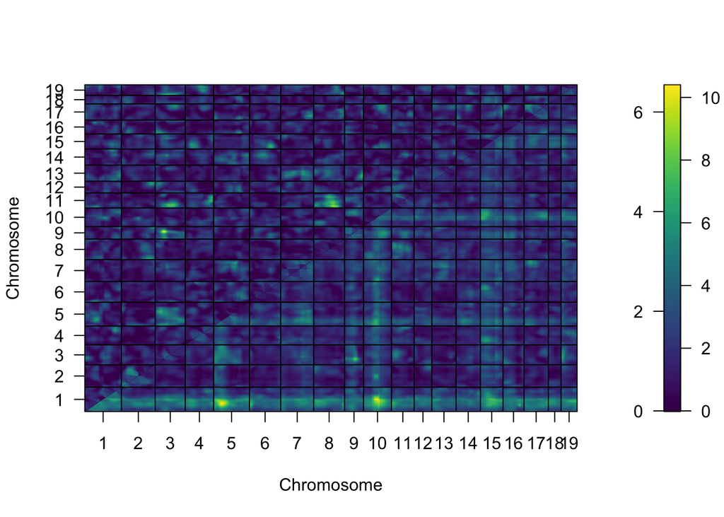

```r
plot(bxa.scan2a)
```

### Scantwo sumary

```r
summary(bxa.scan2a, what="best", thresholds=c(9.1, 7.1, 6.3, 6.3, 3.3))
```

|  | chr1 | chr2 | pos1f | pos2f | lod.full | lod.fv1 | lod.int | pos1a | pos2a | lod.add | lod.av1 |
| --- | --- | --- | --- | --- | --- | --- | --- | --- | --- | --- | --- |
| 5 | 1 | 5 | 34.283 | 22.48 | 10.38149 | 6.514739 | 2.816537 | 46.283 | 18.48 | 7.564958 | 3.698202 |
| 10 | 1 | 10 | 49.283 | 40.00 | 10.21572 | 6.348961 | 2.606212 | 48.283 | 43.00 | 7.609504 | 3.742749 |

### Multiple QTL mapping

We begin by first imputing genotypes. Followed by creating a QTL object that allows us to model the effects from multiple loci jointly.

```r
bxa <- sim.geno(bxa, step=2, n.draws=128, err=0.001)

# Create a QTL object by pulling out imputed genotypes at selected loci.
qtl <- makeqtl(bxa, chr=c(1, 5, 10), pos=c(47.3, 21.5, 42.0))
qtl
```

```
##   QTL object containing imputed genotypes, with 128 imputations.
##
##       name chr    pos n.gen
## Q1  1@48.3   1 48.283     3
## Q2  5@21.5   5 21.480     3
## Q3 10@41.0  10 41.000     3
```

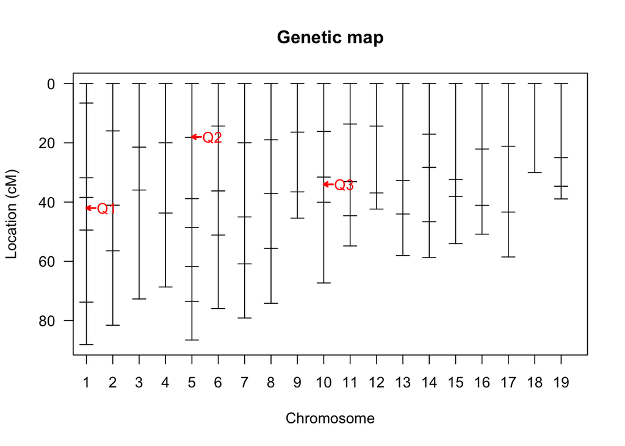

```r
plot(qtl)
```

```r
# Fit a model with selected QTL loci.
out.fq <- fitqtl(bxa, qtl=qtl, formula = y ~ Q1 + Q2 + Q3, pheno.col = 7)
summary(out.fq)
```

```
##
##      fitqtl summary
##
## Method: multiple imputation
## Model:  normal phenotype
## Number of observations : 81
##
## Full model result
## ----------------------------------
## Model formula: y ~ Q1 + Q2 + Q3
##
##       df       SS        MS      LOD     %var Pvalue(Chi2)    Pvalue(F)
## Model  6 308.8143 51.469057 10.17358 43.92098 2.003567e-08 7.761032e-08
## Error 74 394.2992  5.328368
## Total 80 703.1136
##
##
## Drop one QTL at a time ANOVA table:
## ----------------------------------
##         df Type III SS   LOD  %var F value Pvalue(Chi2) Pvalue(F)
## 1@48.3   2      138.31 5.289 19.67  12.979        0.000  1.47e-05 ***
## 5@21.5   2       82.27 3.333 11.70   7.720        0.000  0.000901 ***
## 10@41.0  2       74.74 3.053 10.63   7.014        0.001  0.001625 **
## ---
## Signif. codes:  0 '***' 0.001 '**' 0.01 '*' 0.05 '.' 0.1 ' ' 1
```

### Plot effects

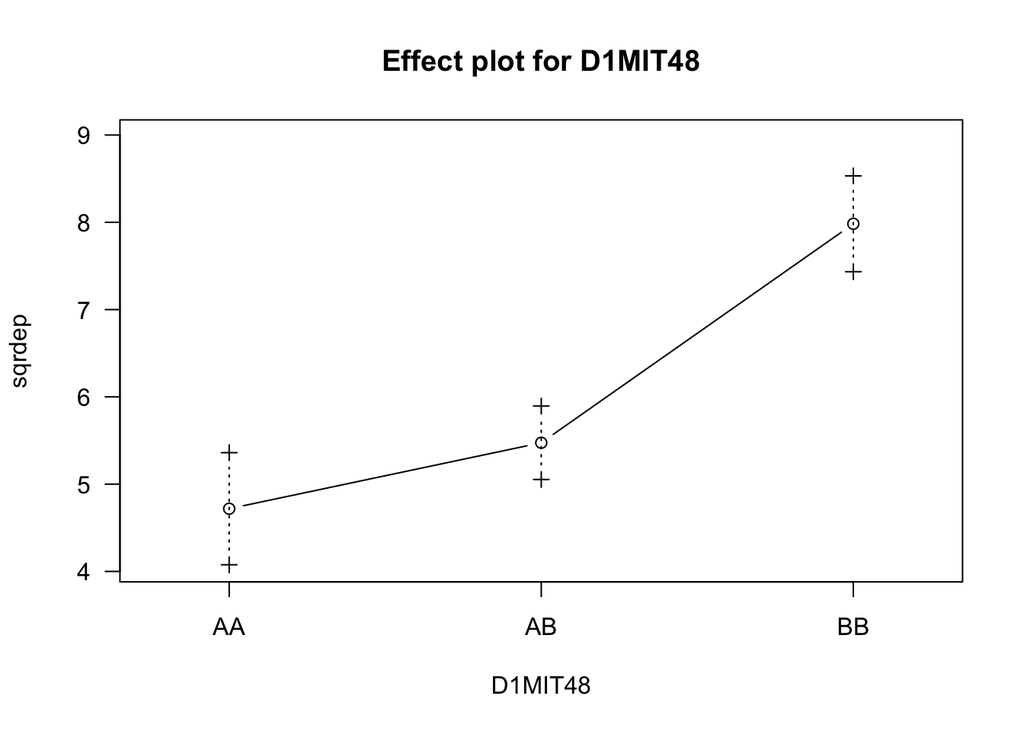

```r
m1<-find.marker(bxa,chr=1, pos=48.3)
m2<-find.marker(bxa,chr=5, pos=21.5)
m3<-find.marker(bxa,chr=10, pos=41.0)

effectplot(bxa,pheno.col=7, mname1=m1)
```

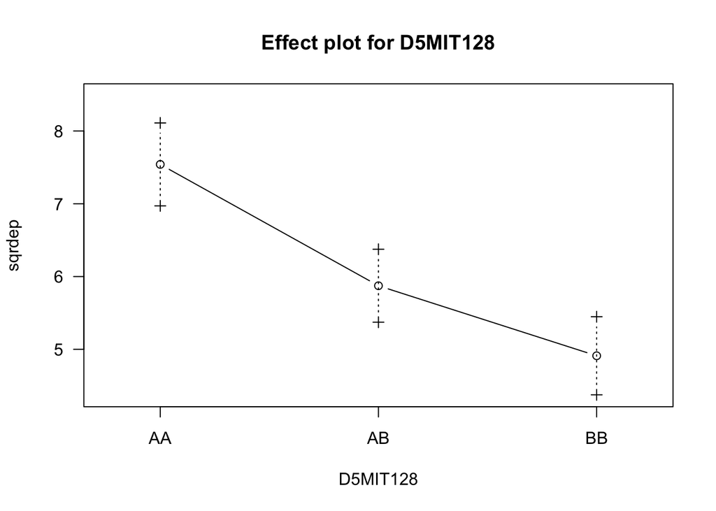

```r
effectplot(bxa,pheno.col=7, mname1=m2)
```

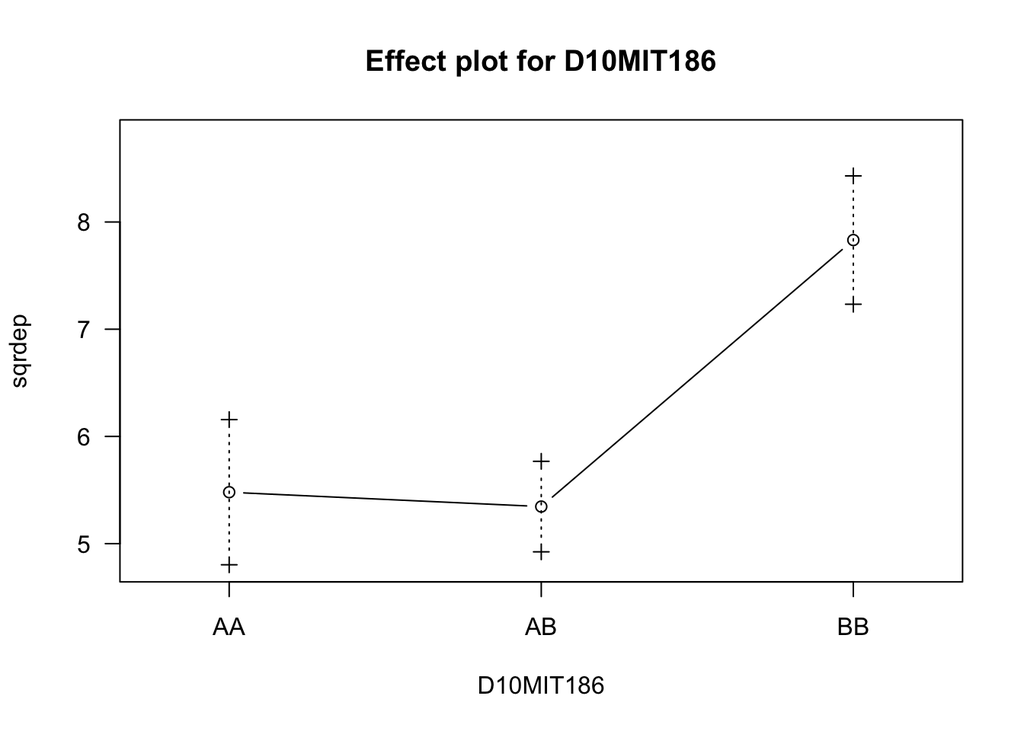

```r
effectplot(bxa,pheno.col=7, mname1=m3)
```

### Plot the phenotype values versus the genotypes at a marker or markers.

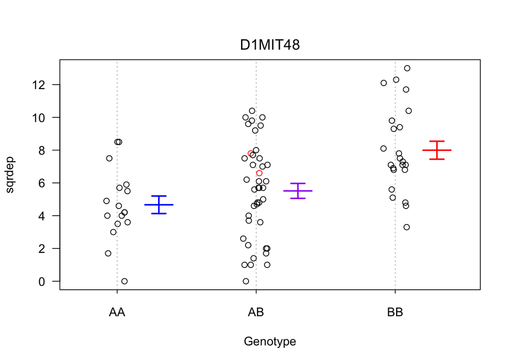

```r
plotPXG(bxa,pheno.col=7, marker=m1)
```

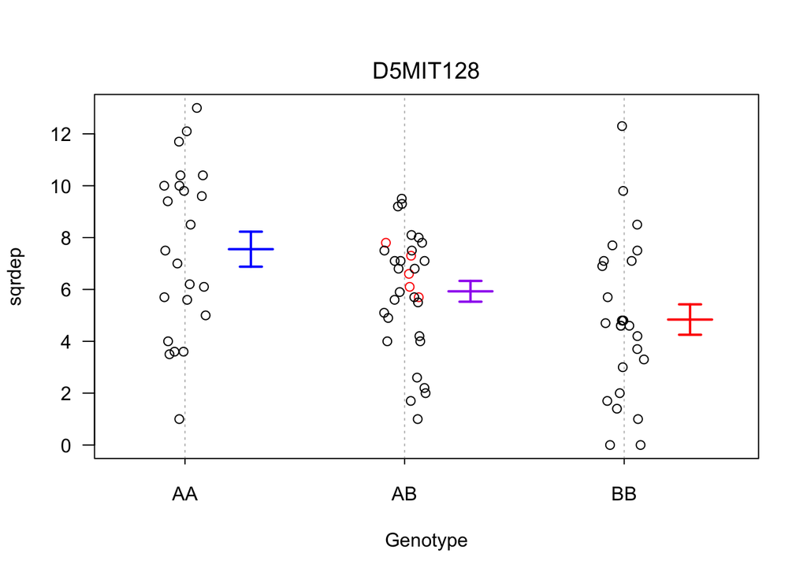

```r
plotPXG(bxa,pheno.col=7, marker=m2)
```

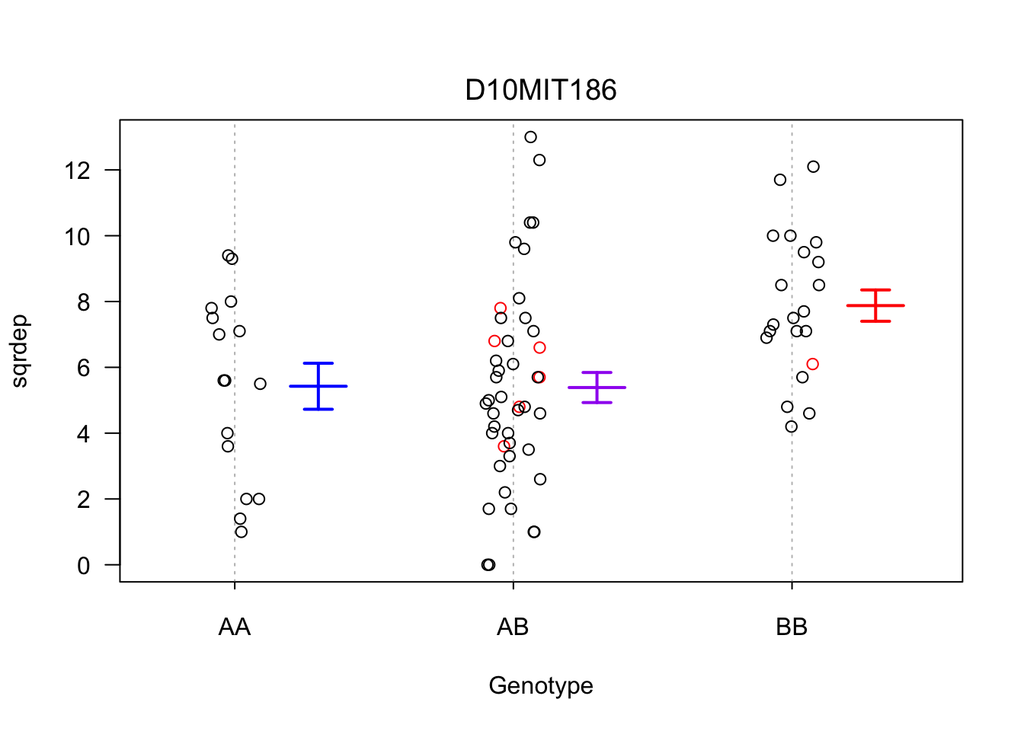

```r
plotPXG(bxa,pheno.col=7, marker=m3)
```